# make up #2

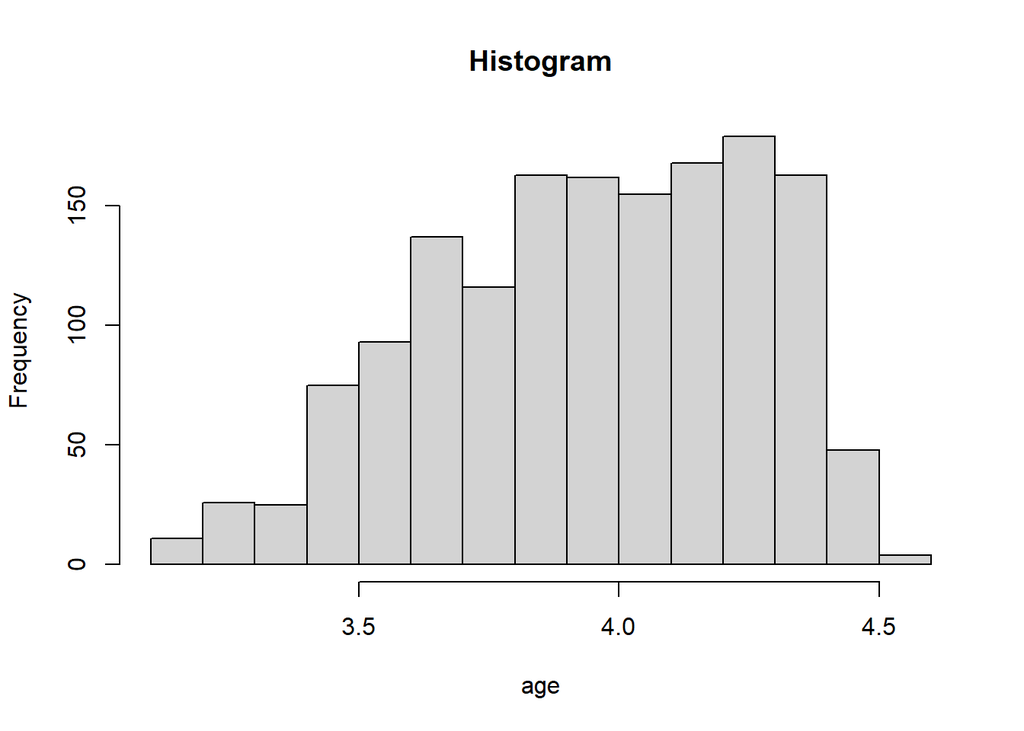

```
## $breaks
##  [1] 3.1 3.2 3.3 3.4 3.5 3.6 3.7 3.8 3.9 4.0 4.1 4.2 4.3 4.4 4.5 4.6
##
## $counts
##  [1]  11  26  25  75  93 137 116 163 162 155 168 179 163  48   4
##
## $density
##  [1] 0.07213 0.17049 0.16393 0.49180 0.60984 0.89836 0.76066 1.06885 1.06230
## [10] 1.01639 1.10164 1.17377 1.06885 0.31475 0.02623
##
## $mids
##  [1] 3.15 3.25 3.35 3.45 3.55 3.65 3.75 3.85 3.95 4.05 4.15 4.25 4.35 4.45 4.55
##
## $xname
## [1] "log.age"
##
## $equidist
## [1] TRUE
##
## attr(,"class")
## [1] "histogram"
```

```r
(h <- with(BEPS,hist(log.age, breaks = bins, xlab = "age", main = "Histogram")))
```

```r
data.frame(Mid=h$mids, Count=h$counts, Roots=sqrt(h$counts))###????
```

```
##     Mid Count  Roots
## 1  3.15    11  3.317
## 2  3.25    26  5.099
## 3  3.35    25  5.000
## 4  3.45    75  8.660
## 5  3.55    93  9.644
## 6  3.65   137 11.705
## 7  3.75   116 10.770
## 8  3.85   163 12.767
## 9  3.95   162 12.728
## 10 4.05   155 12.450
## 11 4.15   168 12.961
## 12 4.25   179 13.379
## 13 4.35   163 12.767
## 14 4.45    48  6.928
## 15 4.55     4  2.000
```

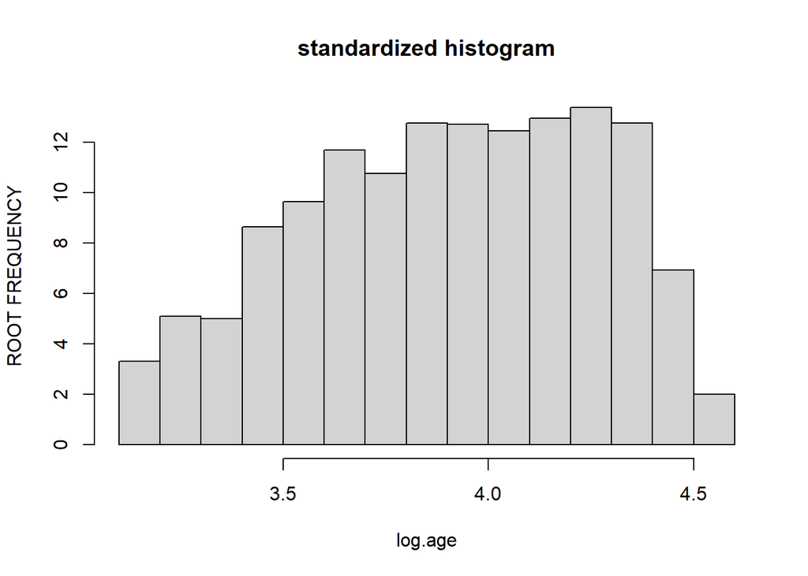

```r
h$counts <- sqrt(h$counts)
plot(h, xlab = "log.age", ylab = "ROOT FREQUENCY", main = "standardized histogram")
```

```r
# Gaussian Resistant measures
(fl.u <- fivenum(BEPS$log.age)[c(2,4)])
```

```
## [1] 3.714 4.205
```

```r
g.mean <- sum(fl.u)/2
g.sd <- diff(fl.u)/1.349

# Standard Resistant measures
median <- median(BEPS$log.age)
df <- IQR(BEPS$log.age)

s <- fit.gaussian(BEPS$log.age, bins, median, df)
s <- fit.gaussian(BEPS$log.age, bins, g.mean, g.sd)

options(digits=4)
(data <- data.frame(Mid=bin.mids, d=s$counts, sqrt.d=sqrt(s$counts),
                    Prob=s$probs, e=s$expected, sqrt.e=sqrt(s$expected),
                    Residual=s$residual))
```

```
##     Mid   d sqrt.d     Prob      e sqrt.e Residual
## 1  3.15  11  3.317 0.009386  14.31  3.783 -0.46666
## 2  3.25  26  5.099 0.016583  25.29  5.029  0.07022
## 3  3.35  25  5.000 0.027182  41.45  6.438 -1.43840
## 4  3.45  75  8.660 0.041338  63.04  7.940  0.72046
## 5  3.55  93  9.644 0.058324  88.94  9.431  0.21261
## 6  3.65 137 11.705 0.076346 116.43 10.790  0.91451
## 7  3.75 116 10.770 0.092718 141.40 11.891 -1.12064
## 8  3.85 163 12.767 0.104467 159.31 12.622  0.14523
## 9  3.95 162 12.728 0.109203 166.53 12.905 -0.17691
## 10 4.05 155 12.450 0.105908 161.51 12.709 -0.25873
## 11 4.15 168 12.961 0.095293 145.32 12.055  0.90655
## 12 4.25 179 13.379 0.079548 121.31 11.014  2.36497
## 13 4.35 163 12.767 0.061608  93.95  9.693  3.07423
## 14 4.45  48  6.928 0.044268  67.51  8.216 -1.28812
## 15 4.55   4  2.000 0.029510  45.00  6.708 -4.70841
```

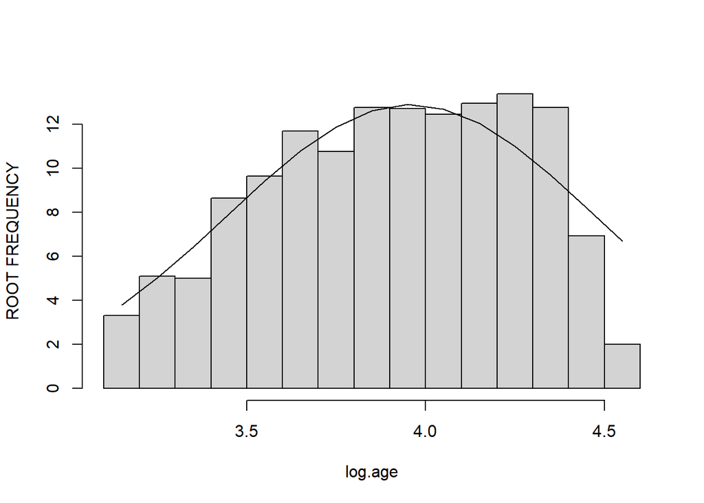

```r
plot(h, xlab = "log.age", ylab = "ROOT FREQUENCY", main = "")

lines(bin.mids, sqrt(s$expected))
```

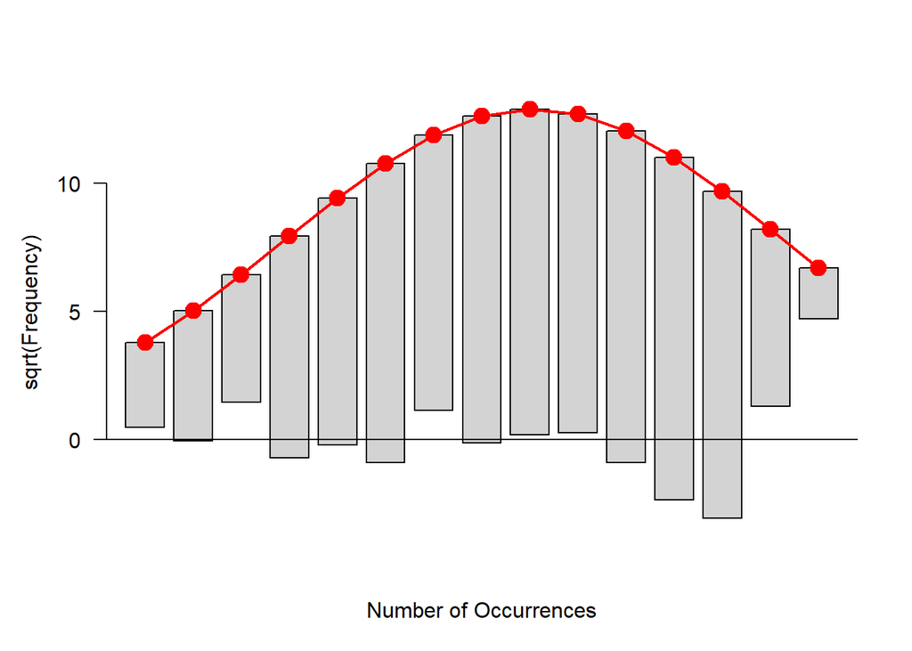

```r
rootogram(s$counts, s$expected)
```

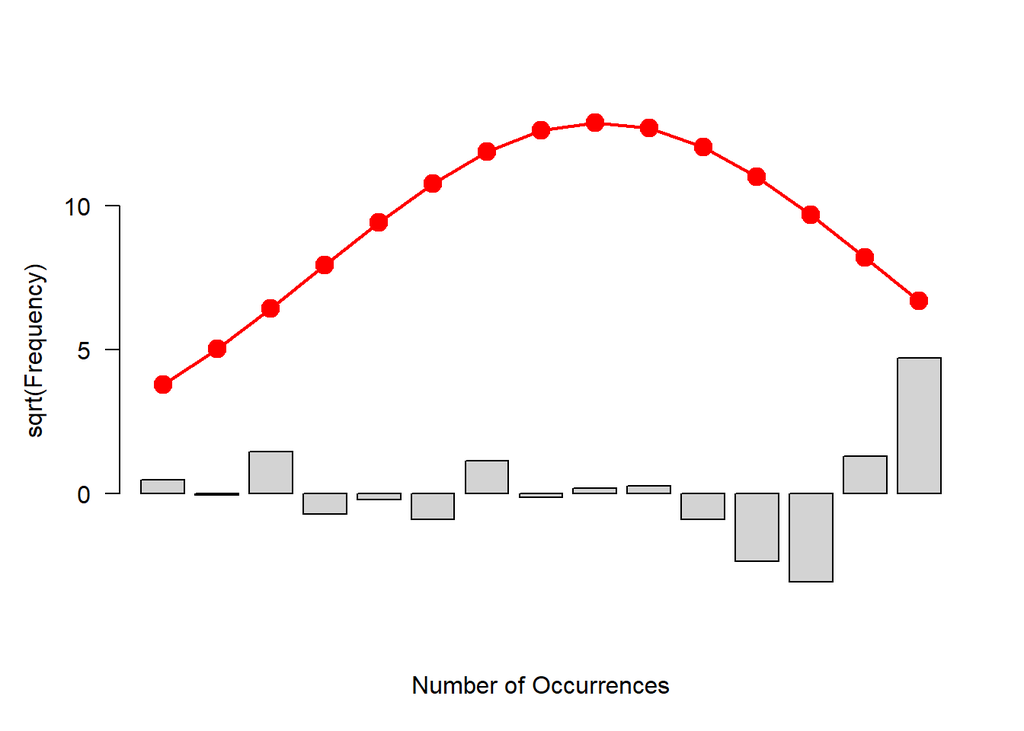

```r
rootogram(s$counts, s$expected, type = 'deviation')
```

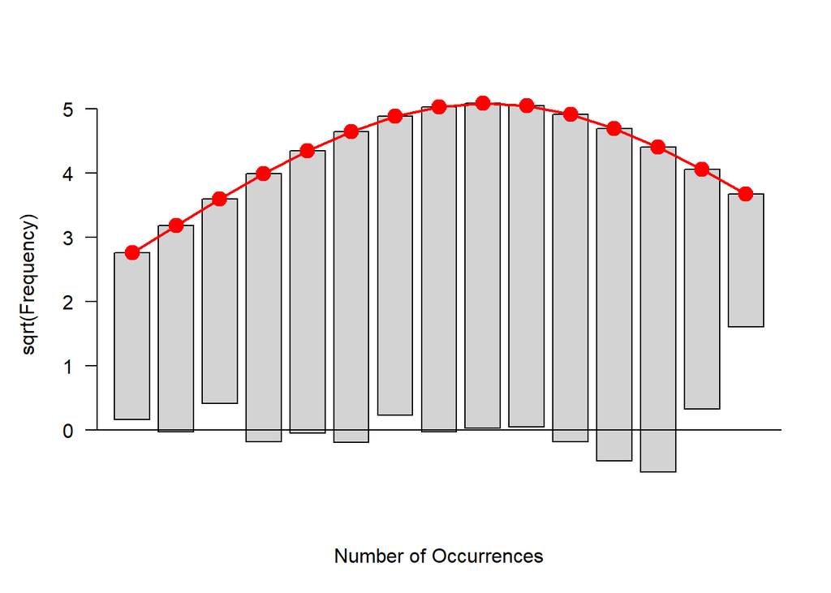

```r
data$drr <- with(data, sqrt(2 + 4*d) - sqrt(1 + 4*e))

# Alternative especially when bins have small counts
with(data, rootogram(sqrt(2 + 4*d), sqrt(1 + 4*e)))
```

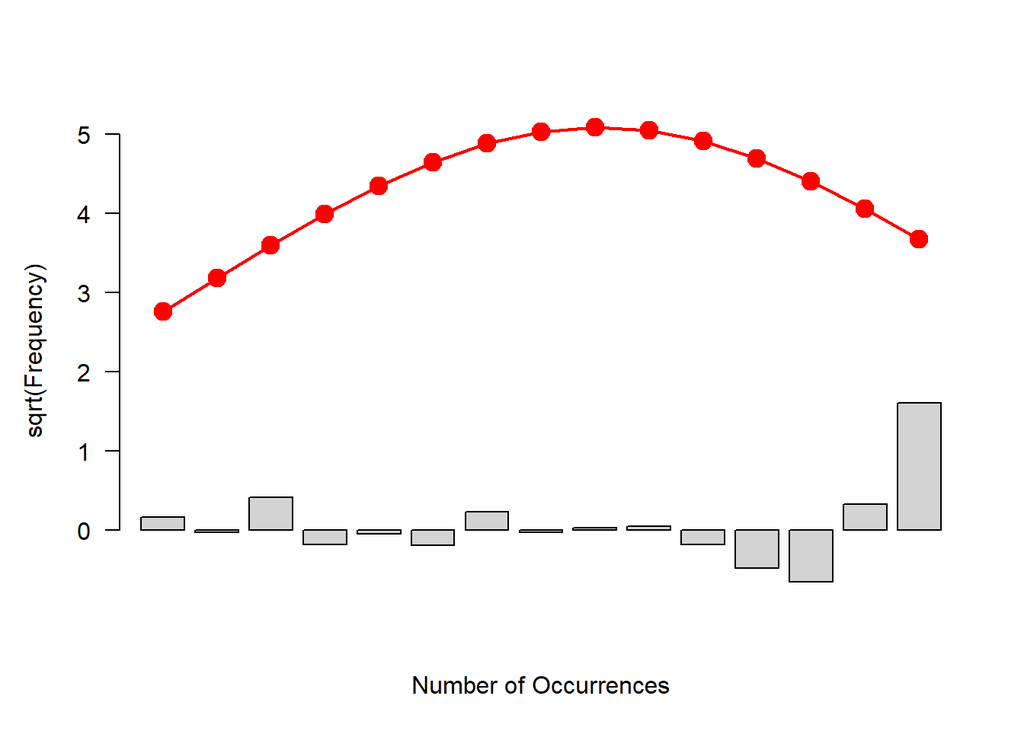

```r
with(data, rootogram(sqrt(2 + 4*d), sqrt(1 + 4*e), type = 'deviation'))
```

> > Tranforming the data does try to improve th fit of the normal curve even thought the tranformation is all the way perfect. I asay this because we still have significant overs and unders now.

```r
lo.68 <- g.mean-g.sd
hi.68 <- g.mean + g.sd
(lo.68.percent <- exp(c(lo.68, hi.68)))
```

```
## [1] 36.42 75.43
```

```r
lo.95 <- g.mean-(2*g.sd)
hi.95 <- g.mean + (2*g.sd)
(lo.95.percent <- exp(c(lo.95, hi.95)))
```

```
## [1]  25.31 108.56
```

> > From the tranformed rootogram, the middle 68% of the data ranges from 36.42 up to 75.43. The middle 95% of the data then is ranging between 25.31 and 108.56.

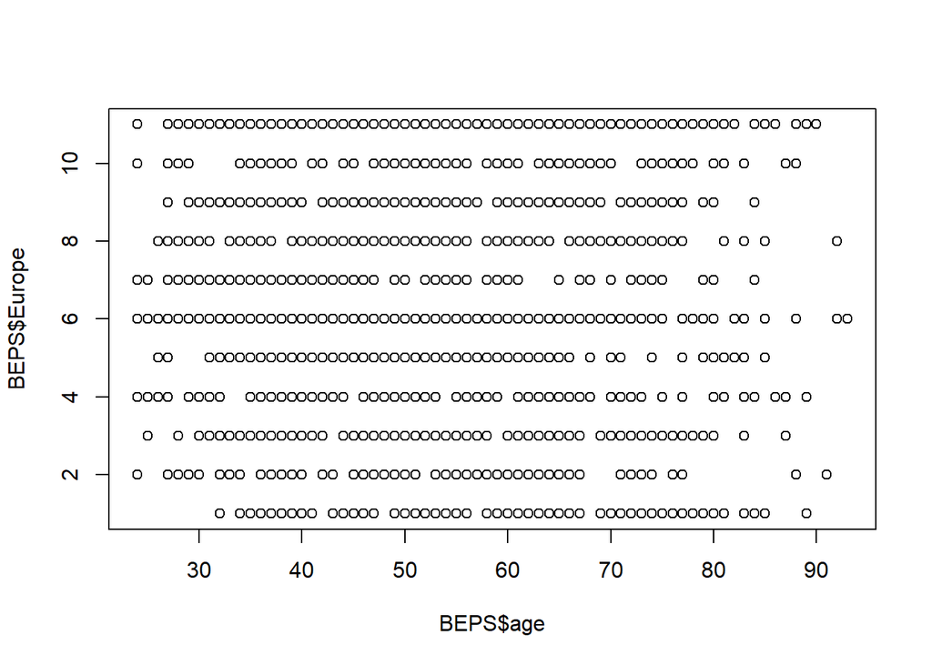

```r
plot(BEPS$age,BEPS$Europe)
```

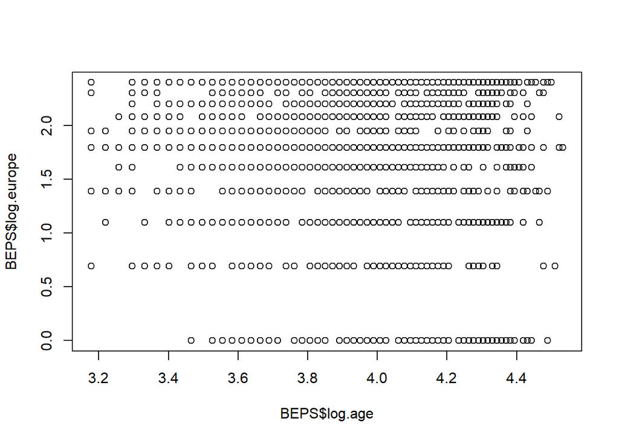

```r
plot(BEPS$log.age,BEPS$log.europe)
```

> > Plotting the age against Eurupe is gives us a horizontaly linear pattern.Even after reexpression the data points are still only linear. This could be because the values of data points are whole numbers themselves.

```r
(sorted.datas <- BEPS[order(BEPS$log.age, decreasing = T),])
```

[output not shown]

[output cut: 3037 more lines]

```r
sorted.datas$group <- as.numeric(cut_number(sorted.datas$log.age, 3)) #dividing data into three groups
length(sorted.datas$log.age)
```

```
## [1] 1525
```

```r
# Counts per group
(n1 <- nrow(sorted.datas[which(sorted.datas$group == 1),]))# which means where
```

```
## [1] 544
```

```r
(n2 <- nrow(sorted.datas[which(sorted.datas$group == 2),]))
```

```
## [1] 478
```

```r
(n3 <- nrow(sorted.datas[which(sorted.datas$group == 3),]))
```

```
## [1] 503
```

```r
# Find divisions between groups
t1 <- first(sorted.datas[which(sorted.datas$group == 1),
                         'log.age'])

t2 <- first(sorted.datas[which(sorted.datas$group == 2),
                         'log.age'])

# find (median x, median y) and put to one data frame
# summary.points <- data.frame(x=c(1.79, 1.87, 2.03),
#                        y=c(2.08, 2.14, 2.31))
head( BEPS)
```

```
##   X             vote age economic.cond.national economic.cond.household Blair
## 1 1 Liberal Democrat  43                      3                       3     4
## 2 2           Labour  36                      4                       4     4
## 3 3           Labour  35                      4                       4     5
## 4 4           Labour  24                      4                       2     2
## 5 5           Labour  41                      2                       2     1
## 6 6           Labour  47                      3                       4     4
##   Hague Kennedy Europe political.knowledge gender log.age log.europe
## 1     1       4      2                   2 female   3.761     0.6931
## 2     4       4      5                   2   male   3.584     1.6094
## 3     2       3      3                   2   male   3.555     1.0986
## 4     1       3      4                   0 female   3.178     1.3863
## 5     1       4      6                   2   male   3.714     1.7918
## 6     4       2      4                   2   male   3.850     1.3863
```

```r
(summary.points <- as.data.frame(
  rbind(
    sapply(sorted.datas[which(sorted.datas$group == 1),
                        c(12,13)], 2, FUN = median),
    sapply(sorted.datas[which(sorted.datas$group == 2),
                        c(12,13)], 2, FUN = median),
    sapply(sorted.datas[which(sorted.datas$group == 3),
                        c(12,13)], 2, FUN = median) #2 means column
  )
)
)
```

```
##   log.age log.europe
## 1   3.624      1.792
## 2   3.989      1.792
## 3   4.277      2.079
```

```r
(slr.full <- lm(log.age ~ log.europe,
                data = sorted.datas))
```

```
##
## Call:
## lm(formula = log.age ~ log.europe, data = sorted.datas)
##
## Coefficients:
## (Intercept)   log.europe
##     3.95017     -0.00147
```

```r
(slr.resistant <- lm(log.age ~ log.europe,  summary.points))
```

```
##
## Call:
## lm(formula = log.age ~ log.europe, data = summary.points)
##
## Coefficients:
## (Intercept)   log.europe
##       0.879        1.634
```

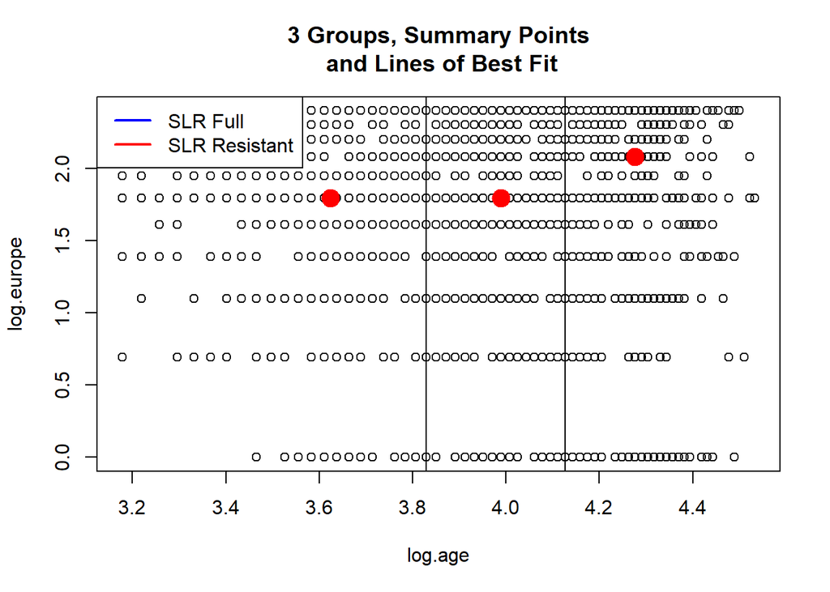

```r
#is rlm model from original data, will it be similar to resistant line
#r.resistant <-rlm(log.2000~log.1985, data = home.prices))




# View plot with 3rds and summary points
with(sorted.datas, plot(log.age,log.europe,
                        main="3 Groups, Summary Points\n and Lines of Best Fit"))
abline(v=t1)
abline(v=t2)
points(summary.points, cex=2, pch=19, col="red")

abline(slr.full, col = "blue")
abline(slr.resistant, col = "red")
legend("topleft", legend = c("SLR Full", "SLR Resistant"),
       col = c("blue", "red"), lwd=2)
```

```r
(myfit <- rline(log.age~log.europe, sorted.datas))
```

```
## $a
## [1] 3.966
##
## $b
## [1] 0.007061
##
## $xC
## [1] 1.792
##
## $half.slope.ratio
## [1] -1.242
##
## $residual
##    [1]  5.666e-01  5.538e-01  5.558e-01  5.526e-01  5.296e-01  5.255e-01
##    [7]  5.353e-01  5.184e-01  5.353e-01  5.353e-01  5.071e-01  5.114e-01
```

[output cut: 259 more lines]

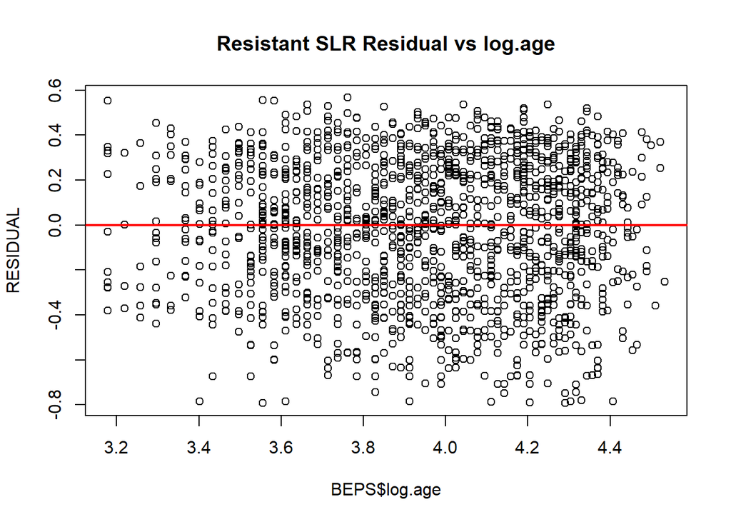

```r
FIT <- with(myfit, a + b * (sorted.datas$log.age - xC))
RESIDUAL <- myfit$residual
options(digits=4) # round everything to 4 digits
BEPS <- data.frame(X = BEPS$X,vote = BEPS$vote,age =  BEPS$age,
                            economic.cond.national = BEPS$economic.cond.national,
                            economic.cond.household = BEPS$economic.cond.household,
                            Blair = BEPS$Blair,Hague = BEPS$Hague,Kennedy = BEPS$Kennedy,
                            Europe = BEPS$Europe, political.knowledge = BEPS$political.knowledge,
                            gender = BEPS$gender, log.age = BEPS$log.age,log.europe = BEPS$log.europe,
                            FIT, RESIDUAL)

# Residual Analysis
plot(BEPS$log.age, RESIDUAL,
     main = 'Resistant SLR Residual vs log.age')
abline(h=0, col = "red", lwd=2)
```

```r
# Finding convergence with iterations from 5 to 10
Results <- data.frame(Iteration=NULL, Slope=NULL, Intercept=NULL)
for(iterations in 1:10){
  fit <- rline(log.europe ~ log.age, BEPS, iter=iterations)
  Results <- rbind(Results,
                   data.frame(Iteration=iterations,
                              Slope=fit$b, Intercept=fit$a))
}
Results
```

```
##    Iteration  Slope Intercept
## 1          1 0.4321     1.895
## 2          2 0.3130     1.920
## 3          3 0.3255     1.917
## 4          4 0.3213     1.918
## 5          5 0.3227     1.918
## 6          6 0.3222     1.918
## 7          7 0.3224     1.918
## 8          8 0.3223     1.918
## 9          9 0.3224     1.918
## 10        10 0.3224     1.918
```

```r
# Median x value
(xc <- summary.points[[2,1]])
```

```
## [1] 3.989
```

```r
# Build linear model
lm(log.europe ~ I(log.age - xc), data = BEPS)
```

```
##
## Call:
## lm(formula = log.europe ~ I(log.age - xc), data = BEPS)
##
## Coefficients:
##     (Intercept)  I(log.age - xc)
##          1.7268          -0.0073
```

```r
# Create an outlier to see difference
(BEPS$Europe.a <- BEPS$Europe)
```

[output not shown]

[output cut: 49 more lines]

```r
(BEPS$Europe.a[331])
```

```
## [1] 11
```

```r
(BEPS$Europe.a[331] <- 10) ##?????
```

```
## [1] 10
```

```r
r <- rline(Europe.a ~ log.age, BEPS, 10)
r[c("a", "b", "xC")]
```

```
## $a
## [1] 6.876
##
## $b
## [1] 2.241
##
## $xC
## [1] 3.97
```

```r
(slr.a <- lm(BEPS$Europe.a ~ I(log.age - r$xC), BEPS))
```

```
##
## Call:
## lm(formula = BEPS$Europe.a ~ I(log.age - r$xC), data = BEPS)
##
## Coefficients:
##       (Intercept)  I(log.age - r$xC)
##             6.745              0.741
```

```r
(slr.a <- lm(BEPS$Europe.a ~ log.age, BEPS))
```

```
##
## Call:
## lm(formula = BEPS$Europe.a ~ log.age, data = BEPS)
##
## Coefficients:
## (Intercept)      log.age
##       3.805        0.741
```

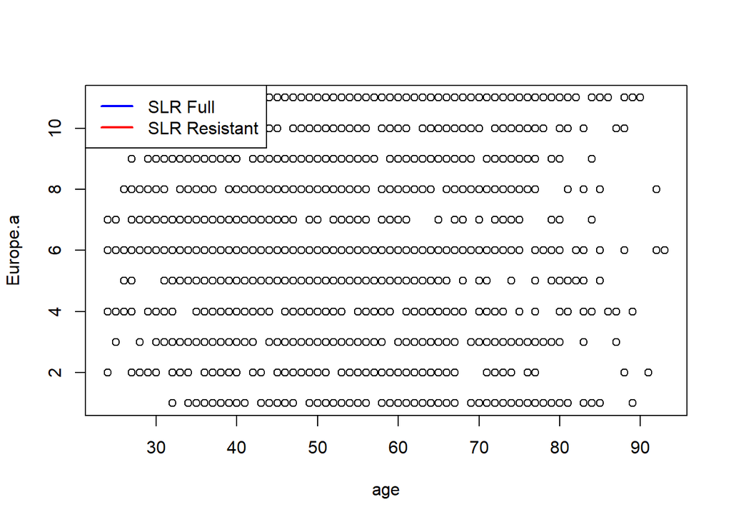

```r
with(BEPS, plot(age, Europe.a))
abline(a = r$a + r$b * -r$xC,
       b = r$b, col = "red")
abline(slr.a, col = "blue")
legend("topleft", legend = c("SLR Full", "SLR Resistant"),
       col = c("blue", "red"), lwd=2)
```

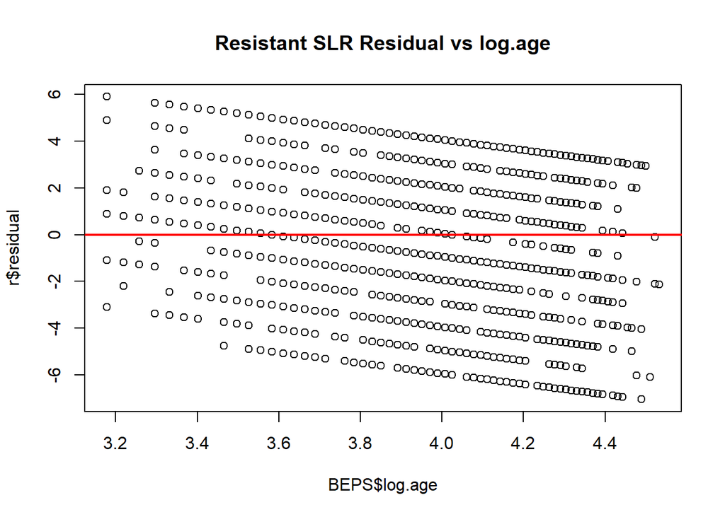

```r
# Resistant v Full Residual Analysis
plot(BEPS$log.age, r$residual,
     main = 'Resistant SLR Residual vs log.age')
abline(h=0, col = "red", lwd=2)
```

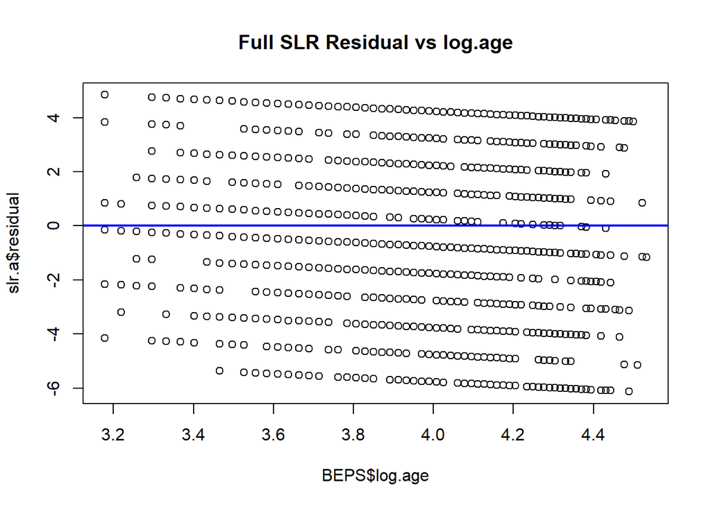

```r
plot(BEPS$log.age, slr.a$residual,
     main = 'Full SLR Residual vs log.age')
abline(h=0, col = "blue", lwd=2)
```